# Practical Machine Learning: Peer Assessment

## Summary

In this project, we examine weight lifting exercise data collected from various accelerometer sensors on the belt, forearm, arm and dumbbell of 6 participants. We use this data to build a model with the primary goal being to predict the type of exercise being performed, given the sensory data.

## Data Transformation

### Loading Required Packages

```r
library(caret)
library(randomForest)
library(rpart)
library(rattle)
set.seed(3233)
```

### Reading Training & Testing Data

```r
trainingOrg <- read.csv("pml-training.csv")
testingOrg <- read.csv("pml-testing.csv")
```

### Choosing Predictors & Making Subsets

```r
subNamesTrain <- grep("^(roll|pitch|yaw|total|gyros|accel|magnet|classe)", names(trainingOrg))
subNamesTest <- grep("^(roll|pitch|yaw|total|gyros|accel|magnet)", names(testingOrg))
training <- trainingOrg[, subNamesTrain]
training$classe <- factor(training$classe)
testing <- testingOrg[, subNamesTest]
```

The subsets are made to remove variables in the dataset that do not help in predicting the exercise class. These are variables such as mean and standard deviation of the raw sensory data for a single person and so they are not as useful as the raw sensory data itself. The **grep()** function in the above code gives the indices of the column names that start with any of the words mentioned in the function.  
By making the above subsets, the number of total predictors is now **52**.

### Cross Validation

Splitting the training data into two groups (training & testing) to perform cross validation.

```r
indTrain <- createDataPartition(training$classe, p = 0.7, list = F)
trainingCV <- training[indTrain, ]
testingCV <- training[-indTrain, ]
dim(trainingCV)
```

```
## [1] 13737    53
```

```r
dim(testingCV)
```

```
## [1] 5885   53
```

## Creating Models

Building two models, decision trees and random forest, then choosing the one with higher accuracy.

### 1. Decision Trees

```r
modelDT <- rpart(factor(classe) ~ ., method = "class", data = trainingCV)
```

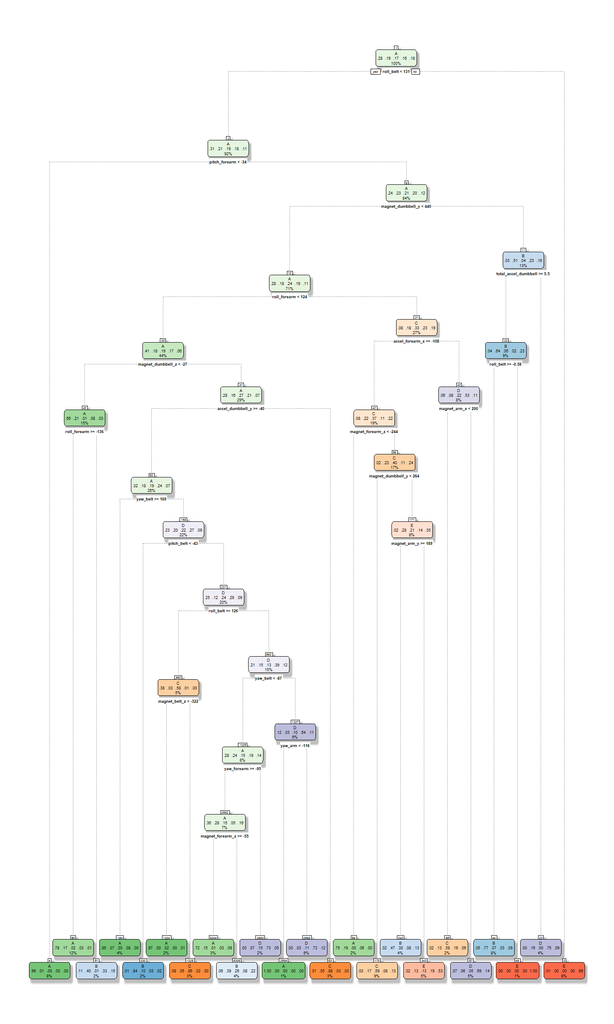

```r
fancyRpartPlot(modelDT, sub = "")
```

```r
cmDT <- confusionMatrix(predict(modelDT, testingCV, type = "class"), testingCV$classe)
cmDT
```

```
## Confusion Matrix and Statistics
##
##           Reference
## Prediction    A    B    C    D    E
##          A 1552  204   11   40   22
##          B   59  691  170  109  159
##          C   34  121  725   77   77
##          D   23   79   81  676  125
##          E    6   44   39   62  699
##
## Overall Statistics
##
##                Accuracy : 0.738
##                  95% CI : (0.7265, 0.7492)
##     No Information Rate : 0.2845
##     P-Value [Acc > NIR] : < 2.2e-16
##
##                   Kappa : 0.6675
##
##  Mcnemar's Test P-Value : < 2.2e-16
##
## Statistics by Class:
##
##                      Class: A Class: B Class: C Class: D Class: E
## Sensitivity            0.9271   0.6067   0.7066   0.7012   0.6460
## Specificity            0.9342   0.8953   0.9364   0.9374   0.9686
## Pos Pred Value         0.8486   0.5816   0.7012   0.6870   0.8224
## Neg Pred Value         0.9699   0.9046   0.9380   0.9412   0.9239
## Prevalence             0.2845   0.1935   0.1743   0.1638   0.1839
## Detection Rate         0.2637   0.1174   0.1232   0.1149   0.1188
## Detection Prevalence   0.3108   0.2019   0.1757   0.1672   0.1444
## Balanced Accuracy      0.9307   0.7510   0.8215   0.8193   0.8073
```

As we can see the accuracy of the decision trees model is **0.738** which is not optimal.

### 2. Random Forest

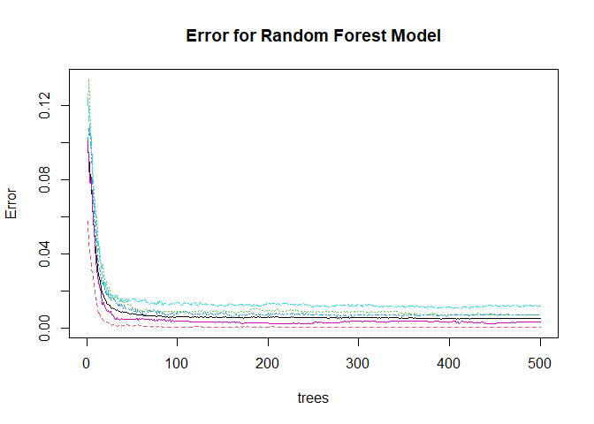

```r
modelRF <- randomForest(factor(classe) ~ ., method = "class", data = trainingCV)
plot(modelRF, main = "Error for Random Forest Model")
```

We can see that as the number of trees increases, the error decreases to approximately zero.

```r
cmRF <- confusionMatrix(predict(modelRF, testingCV), testingCV$classe)
cmRF
```

```
## Confusion Matrix and Statistics
##
##           Reference
## Prediction    A    B    C    D    E
##          A 1674    6    0    0    0
##          B    0 1130    8    0    0
##          C    0    3 1017    6    3
##          D    0    0    1  958    3
##          E    0    0    0    0 1076
##
## Overall Statistics
##
##                Accuracy : 0.9949
##                  95% CI : (0.9927, 0.9966)
##     No Information Rate : 0.2845
##     P-Value [Acc > NIR] : < 2.2e-16
##
##                   Kappa : 0.9936
##
##  Mcnemar's Test P-Value : NA
##
## Statistics by Class:
##
##                      Class: A Class: B Class: C Class: D Class: E
## Sensitivity            1.0000   0.9921   0.9912   0.9938   0.9945
## Specificity            0.9986   0.9983   0.9975   0.9992   1.0000
## Pos Pred Value         0.9964   0.9930   0.9883   0.9958   1.0000
## Neg Pred Value         1.0000   0.9981   0.9981   0.9988   0.9988
## Prevalence             0.2845   0.1935   0.1743   0.1638   0.1839
## Detection Rate         0.2845   0.1920   0.1728   0.1628   0.1828
## Detection Prevalence   0.2855   0.1934   0.1749   0.1635   0.1828
## Balanced Accuracy      0.9993   0.9952   0.9944   0.9965   0.9972
```

The random forest model gives almost perfect **accuracy (0.995)** on our test set (subset of training set) and so we will choose this model to perform prediction on the original test set.  
The **out of sample error** in this case is **0.005** with a confidence interval of **(0.0034, 0.0073)** which is very low.

## Predicting From Test Data Using Random Forest Model

```r
predict(modelRF, testing)
```

```
##  1  2  3  4  5  6  7  8  9 10 11 12 13 14 15 16 17 18 19 20
##  B  A  B  A  A  E  D  B  A  A  B  C  B  A  E  E  A  B  B  B
## Levels: A B C D E
```